# Self Generating Panels

Adam A. Kemberling

2022-06-01

# Writing Code that Writes Itself

Original inspiration for this guide comes from here: [interlude one](https://interludeone.com/posts/2022-03-04-programmatically-generate-tabs-in-rmarkdown/?panelset=dream&panelset1=torgersen2)

This markdown details a common workflow simplification in two parts: 1. Writing a function for repeating plots 2. Writing a function that will make tabs for each one

## Inspiration

A common repetetive task when doing any multi-species analysis is exploring the data in a similar way, but for each species. Using the Palmer Penguins Data as an example, we might want to see the relationship between bill length and flipper length, but for each species and maybe facet it for each island.

### Simple Example:

For one species the code would look something like this:

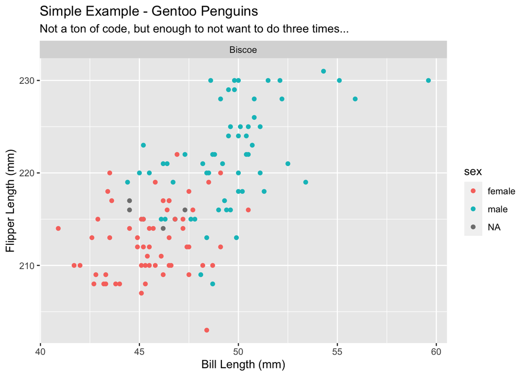

```r
library(palmerpenguins)
library(tidyverse)
library(gmRi)

# Step 1: Filter the species
spec_dat <- penguins %>% filter(species == "Gentoo")

# Step 2: Plot Relationship
ggplot(spec_dat, aes(bill_length_mm, flipper_length_mm, color = sex)) +
  geom_point() +
  facet_wrap(~island) +
  labs(x = "Bill Length (mm)",
       y = "Flipper Length (mm)",
       title = "Simple Example - Gentoo Penguins",
       subtitle = "Not a ton of code, but enough to not want to do three times...")
```

## How Even Simple Code Fails to Scale

Without making the plot in that simple example a function, we need to copy and paste all the code for the remaining species:

```r
# Step 1: Filter the species
spec_dat <- penguins %>% filter(species == "Adelie")

# Step 2: Plot Relationship
ggplot(spec_dat, aes(bill_length_mm, flipper_length_mm, color = sex)) +
  geom_point() +
  facet_wrap(~island) +
  labs(x = "Bill Length (mm)",
       y = "Flipper Length (mm)",
       title = "Adelie Penguins")
```

[output not shown]

```r
# Step 1: Filter the species
spec_dat <- penguins %>% filter(species == "Chinstrap")

# Step 2: Plot Relationship
ggplot(spec_dat, aes(bill_length_mm, flipper_length_mm, color = sex)) +
  geom_point() +
  facet_wrap(~island) +
  labs(x = "Bill Length (mm)",
       y = "Flipper Length (mm)",
       title = "Chinstrap Penguins")
```

[output not shown]

We’ve now repeated a bunch of code, making the markdown long. And now if we wanted to tweak the plot in some way, we would need to do it in each location, which we don’t want to do because it makes more work for us. Adding insult to injury, we either have to write over the same object in the environment which can lead to problems if you mess up, or you need to create a bunch of clutter in the environment. **These are all bad patterns.**

See [DRY Principal](https://deviq.com/principles/dont-repeat-yourself).

## Reduce Repetition Using Abstraction

One way to reduce the “copy and paste” is with a function for the plot. Functions are useful when we want to abstract a repeated process, by isolating the elements that change from those that do not.

In this case the only things that change with each iteration is the species we filter the data with, and the plot text it generates. So in practice this is the only argument we need for the function:

```r
# Make a function for how the plot should look:
plot_fun <- function(spec_id){

  # Step 1: Filter the species
  spec_dat <- penguins %>% filter(species == spec_id)

  # Step 2: Plot Relationship
  p <- ggplot(spec_dat, aes(bill_length_mm, flipper_length_mm, color = sex)) +
    geom_point() +
    facet_wrap(~island) +
    labs(x = "Bill Length (mm)",
         y = "Flipper Length (mm)",
         title = paste(spec_id, "Penguins"))

  # Step 3: Return the plot as output
  return(p)

}
```

# Organize Contents with Tabs/ Panels

One thing I like to do that I think helps reduce the clutter in a big markdown report, is to swap out what plots display using tabs or panels.

**This is what that looks like in practice:**

## How do Tabs Work?

Tabs can be created by including the text: `{tabset}` beside a header `## Header` in an rmarkdown document. Once this is done, the successive sub headers (Headers that are one `#` more than the header with `{tabset}` beside it) become their own tabs.

In this example the header that starts it is `## How do Tabs Work? {.tabset}`, and the following tabs begin with: `### Gentoo` & `### Adelie`.

### Gentoo

```r
plot_fun("Gentoo")
```

[output not shown]

### Adelie

```r
plot_fun("Adelie")
```

[output not shown]

## Panels with xaringanExtra::panelset()

Similar to tabs, the {xaringanExtra} package allows for the use of panels. These can be created similarly using `{.panelset}` instead of tabset:

```r
xaringanExtra::use_panelset()
```

### Gentoo

```r
plot_fun("Gentoo")
```

[output not shown]

### Chinstrap

```r
plot_fun("Chinstrap")
```

[output not shown]

# Streamling Markdown with Generative Panels

The above setup is how I had been doing it for quite some time, but I found myself creating a lot of tabs with essentially the same code in each one, which was a sign that they likely could be automated.

After some googling I came across this tutorial for achieving self-generating panels: https://interludeone.com/posts/2022-03-04-programmatically-generate-tabs-in-rmarkdown/

```r
# Function to generate panels using a key word and a plot function
plot_panelset <- function(spec, plot_fun, ...) {

  # Open panel
  cat("::: {.panel}\n")
  # Create header for panel name
  cat("##", spec, "{.panel-name}\n")
  # # Text as a plot description
  # cat("Plot of", spec, "\n")
  # Make plot
  p <- plot_fun(spec, ...)
  print(p)
  # Add linebreak
  cat("\n")
  # Close panel
  cat(":::\n")
}
```

## Reducing Code with Panel Generator

The key to this working is a function that takes two inputs:  
1. The keyword that will be the name of a panel  
2. A plotting function that takes that same keyword

Once those pieces exist it simply is a matter of looping through them in an r chunk with `results = "asis"` and sandwiching it all between these strange looking “fenced divs”.

````
::::: {.panelset}


# ```{r, results = "asis"}
# purrr::walk(
#   .x = c("Gentoo", "Chinstrap", "Adelie"),
#   .f = plot_panelset,
#   plot_fun = plot_fun
# )
# ```


:::::
````

```r
purrr::walk(
  .x = c("Gentoo", "Chinstrap", "Adelie"),
  .f = plot_panelset,
  plot_fun = plot_fun
)
```

[output not shown]

### Request for help:

I feel pretty confident that this can be done with {.tabset} which would avoid loading in a package or relying on `xaringanExtra::panelset()`.

Feel free to mess around and figure this out for the group good!